# ggstackplot

# The `template` argument

## Theme modifications

Add any modification to the overlying theme as you see fit.

Here, `template` allows the user to define that a `ggplot()` will serve as the base, with `geom_line` as the primary geom. Then, `theme_stackplot()` is applied and custom `theme()` options are set.

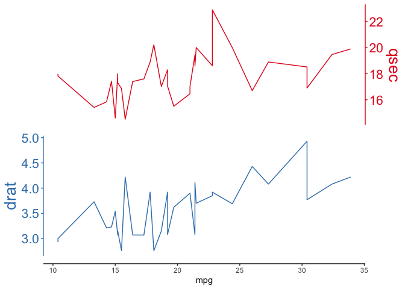

```r
library(ggplot2)

# increase y axis text size
mtcars |>
  ggstackplot(
    x = mpg, y = c(qsec, drat),
    color = c("#E41A1C", "#377EB8"),
    template =
      ggplot() +
      geom_line() +
      theme_stackplot() +
      theme(
        axis.title.y = element_text(size = 20),
        axis.text.y = element_text(size = 16)
      )
  )
```

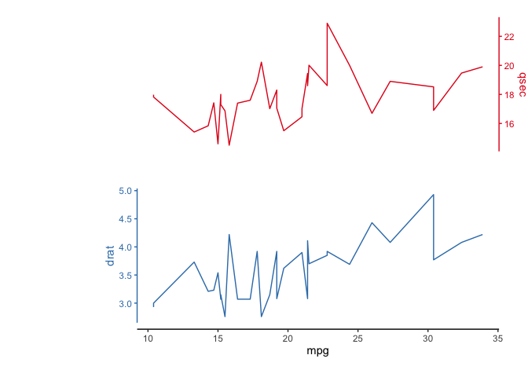

```r
# increase the panel margins
mtcars |>
  ggstackplot(
    x = mpg, y = c(qsec, drat),
    color = c("#E41A1C", "#377EB8"),
    template =
      ggplot() +
      geom_line() +
      theme_stackplot() +
      theme(
        # increase left margin to 20% and top/bottom margins to 10%
        plot.margin = margin(l = 0.2, t = 0.1, b = 0.1, unit = "npc")
      )
  )
```

## Grid modifications

Modifying the `panel.grid` argument can create gridlines for both the stacked variable axes and the shared axis. This can get a bit cluttered in a plot where `overlap = 1`.

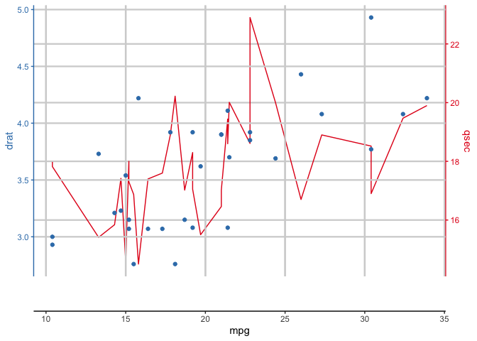

```r
mtcars |>
  ggstackplot(
    x = mpg, y = c(qsec, drat),
    color = c("#E41A1C", "#377EB8"),
    overlap = 1,
    template = ggplot() +
      geom_line(data = function(df) filter(df, .yvar == "qsec")) +
      geom_point(data = function(df) filter(df, .yvar == "drat")) +
      theme_stackplot() +
      theme(
        panel.grid.major = element_line(
          color = "lightgray",
          linewidth = 0.8)
      )
  )
```

But, this can look reasonable if there is no overlap of the stacked plats, and/or if the lines are made inconspicuous:

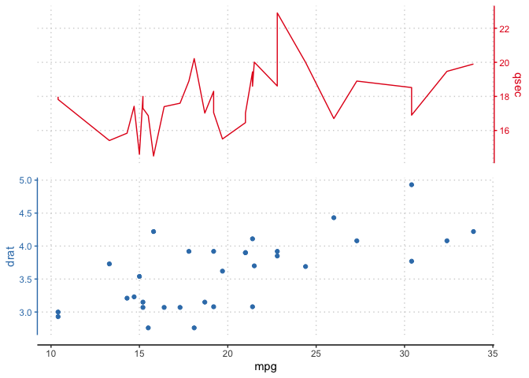

```r
mtcars |>
  ggstackplot(
    x = mpg, y = c(qsec, drat),
    color = c("#E41A1C", "#377EB8"),
    overlap = 0,
    template = ggplot() +
      geom_line(data = function(df) filter(df, .yvar == "qsec")) +
      geom_point(data = function(df) filter(df, .yvar == "drat")) +
      theme_stackplot() +
      theme(
        panel.grid.major = element_line(
          color = "lightgray",
          linetype = "dotted",
          linewidth = 0.5)
      )
  )
```